# HW2

2.a

```r
data$agesq = data$age^2
model2.0 = lm(sleep~totwrk+educ+age+agesq+male+yngkid)
summary(model2.0)
```

```
##
## Call:
## lm(formula = sleep ~ totwrk + educ + age + agesq + male + yngkid)
##
## Residuals:
##      Min       1Q   Median       3Q      Max
## -2378.00  -243.29     6.73   259.24  1350.19
##
## Coefficients:
##               Estimate Std. Error t value Pr(>|t|)
## (Intercept) 3840.85207  239.41393  16.043   <2e-16 ***
## totwrk        -0.16342    0.01816  -8.997   <2e-16 ***
## educ         -11.71327    5.87195  -1.995   0.0465 *
## age           -8.69740   11.32909  -0.768   0.4429
## agesq          0.12844    0.13467   0.954   0.3405
## male          87.75455   34.66794   2.531   0.0116 *
## yngkid        -0.02280   50.27641   0.000   0.9996
## ---
## Signif. codes:  0 '***' 0.001 '**' 0.01 '*' 0.05 '.' 0.1 ' ' 1
##
## Residual standard error: 418 on 699 degrees of freedom
## Multiple R-squared:  0.1228, Adjusted R-squared:  0.1152
## F-statistic:  16.3 on 6 and 699 DF,  p-value: < 2.2e-16
```

Nem igazan javult a modellunk model2 ota, de ketsegtelenul javult valamennyit

2.c

```r
library(lmtest)
bptest(model2.0)
```

```
##
##  studentized Breusch-Pagan test
##
## data:  model2.0
## BP = 11.029, df = 6, p-value = 0.0875
```

A Breusch-Pagan teszt erteke: 11.029, 6-os szabadságfok mellett, p-értéke pedig 0.0875. 5%-os szignifikancia szinten tehát nem tudjuk elvetni a nullhipotézist, vagyis esetünkben heteroszkedaszticitás nem áll fenn.

2.d

```r
model2.1 = lm(sleep~age+wrktype+educ+yngkid, data)
summary(model2.1)
```

```
##
## Call:
## lm(formula = sleep ~ age + wrktype + educ + yngkid, data = data)
##
## Residuals:
##      Min       1Q   Median       3Q      Max
## -2392.56  -244.32     7.98   258.91  1273.96
##
## Coefficients:
##                         Estimate Std. Error t value Pr(>|t|)
## (Intercept)             3564.357    128.513  27.735  < 2e-16 ***
## age                        2.699      1.553   1.738   0.0826 .
## wrktypeRészmunkaidos    -143.075     77.218  -1.853   0.0643 .
## wrktypeTeljes munkaidos -338.267     74.712  -4.528 7.01e-06 ***
## educ                     -11.718      6.051  -1.937   0.0532 .
## yngkid                    25.598     50.915   0.503   0.6153
## ---
## Signif. codes:  0 '***' 0.001 '**' 0.01 '*' 0.05 '.' 0.1 ' ' 1
##
## Residual standard error: 429.3 on 700 degrees of freedom
## Multiple R-squared:  0.07341,    Adjusted R-squared:  0.06679
## F-statistic: 11.09 on 5 and 700 DF,  p-value: 2.679e-10
```

```r
prediction = 3564.357+40*2.699-338.267+12*(-11.718)+25.598
prediction
```

```
## [1] 3219.032
```

Egy a feladatban leirt ferfi becsult erteke a model2.1bol 3219.032

2. e

```r
modell4.1 <- lm(sleep~I(totwrk-40)+I(age-40)+I(agesq-40^2)+I(educ-12)+I(male-1)+I(yngkid-1), data)

summary(modell4.1)
```

```
##
## Call:
## lm(formula = sleep ~ I(totwrk - 40) + I(age - 40) + I(agesq -
##     40^2) + I(educ - 12) + I(male - 1) + I(yngkid - 1), data = data)
##
## Residuals:
##      Min       1Q   Median       3Q      Max
## -2378.00  -243.29     6.73   259.24  1350.19
##
## Coefficients:
##                   Estimate Std. Error t value Pr(>|t|)
## (Intercept)     3639.09795   68.19454  53.363   <2e-16 ***
## I(totwrk - 40)    -0.16342    0.01816  -8.997   <2e-16 ***
## I(age - 40)       -8.69740   11.32909  -0.768   0.4429
## I(agesq - 40^2)    0.12844    0.13467   0.954   0.3405
## I(educ - 12)     -11.71327    5.87195  -1.995   0.0465 *
## I(male - 1)       87.75455   34.66794   2.531   0.0116 *
## I(yngkid - 1)     -0.02280   50.27641   0.000   0.9996
## ---
## Signif. codes:  0 '***' 0.001 '**' 0.01 '*' 0.05 '.' 0.1 ' ' 1
##
## Residual standard error: 418 on 699 degrees of freedom
## Multiple R-squared:  0.1228, Adjusted R-squared:  0.1152
## F-statistic:  16.3 on 6 and 699 DF,  p-value: < 2.2e-16
```

```r
se_error <- sqrt(summary_modell4.1$coefficients[2,1]^2+summary_modell4.1$sigma^2)
```

[output not shown]

```
## Error in eval(expr, envir, enclos): object 'summary_modell4.1' not found
```

```r
se_error
```

```
## Error in eval(expr, envir, enclos): object 'se_error' not found
```

```r
 maradek = resid(model2.1)
summary(maradek)
```

```
##      Min.   1st Qu.    Median      Mean   3rd Qu.      Max.
## -2392.564  -244.322     7.985     0.000   258.911  1273.962
```

```r
library(stargazer)
stargazer(model2.1, type = "text")
```

```
##
## ===================================================
##                             Dependent variable:
##                         ---------------------------
##                                    sleep
## ---------------------------------------------------
## age                               2.699*
##                                   (1.553)
##
## wrktypeRészmunkaidos             -143.075*
##                                  (77.218)
##
## wrktypeTeljes munkaidos         -338.267***
##                                  (74.712)
##
## educ                             -11.718*
##                                   (6.051)
##
## yngkid                            25.598
##                                  (50.915)
##
## Constant                       3,564.357***
##                                  (128.513)
##
## ---------------------------------------------------
## Observations                        706
## R2                                 0.073
## Adjusted R2                        0.067
## Residual Std. Error         429.316 (df = 700)
## F Statistic               11.091*** (df = 5; 700)
## ===================================================
## Note:                   *p<0.1; **p<0.05; ***p<0.01
```

```r
# konkrét érték standard hibája:
sqrt(var(data$sleep))/sqrt(706)
```

```
## [1] 16.72572
```

```r
# Várható érték standard hibája
sqrt(var(predict(model2.1)))/sqrt(706)
```

```
## [1] 4.531577
```

a parameterek standard hibaja sorra : 1.553 77.218 74.712 6.051 50.915 128.513

2.f

```r
library(stargazer)
stargazer(model2.1, type = "text")
```

```
##
## ===================================================
##                             Dependent variable:
##                         ---------------------------
##                                    sleep
## ---------------------------------------------------
## age                               2.699*
##                                   (1.553)
##
## wrktypeRészmunkaidos             -143.075*
##                                  (77.218)
##
## wrktypeTeljes munkaidos         -338.267***
##                                  (74.712)
##
## educ                             -11.718*
##                                   (6.051)
##
## yngkid                            25.598
##                                  (50.915)
##
## Constant                       3,564.357***
##                                  (128.513)
##
## ---------------------------------------------------
## Observations                        706
## R2                                 0.073
## Adjusted R2                        0.067
## Residual Std. Error         429.316 (df = 700)
## F Statistic               11.091*** (df = 5; 700)
## ===================================================
## Note:                   *p<0.1; **p<0.05; ***p<0.01
```

```r
confint(model2.1)
```

```
##                                2.5 %       97.5 %
## (Intercept)             3312.0407417 3816.6732260
## age                       -0.3496694    5.7484182
## wrktypeRészmunkaidos    -294.6817957    8.5320978
## wrktypeTeljes munkaidos -484.9545167 -191.5798825
## educ                     -23.5970968    0.1618628
## yngkid                   -74.3676592  125.5629442
```

2.g Az f feladatresznel kellett felteteleznunk a residumok normalitasat

2.h

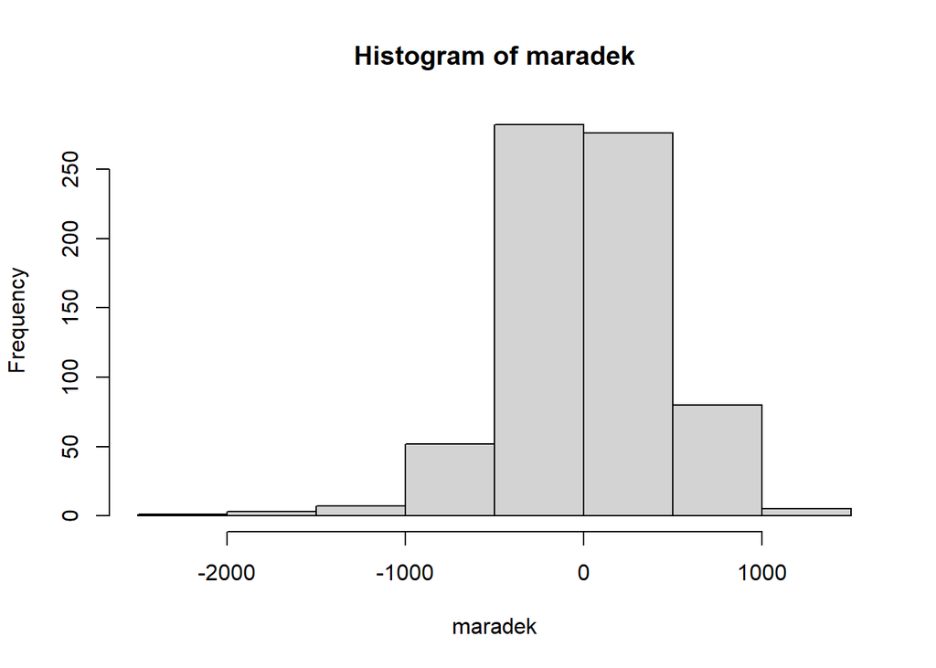

```r
hist(maradek)
```

A hisztogram alapjan a normalitas feltetelezheto

2.i

```r
dt = sort(sample(nrow(data), nrow(data)*.5))
train<-data[dt,]
test<-data[-dt,]
attach(train)
model2.1_train = lm(sleep~age+wrktype+educ+yngkid)
summary(model2.1_train)
```

```
##
## Call:
## lm(formula = sleep ~ age + wrktype + educ + yngkid)
##
## Residuals:
##     Min      1Q  Median      3Q     Max
## -1406.4  -249.6    -3.8   253.8  1258.4
##
## Coefficients:
##                         Estimate Std. Error t value Pr(>|t|)
## (Intercept)             3673.607    173.524  21.171  < 2e-16 ***
## age                        1.683      2.110   0.797 0.425763
## wrktypeRészmunkaidos    -127.234     94.920  -1.340 0.180978
## wrktypeTeljes munkaidos -314.304     90.784  -3.462 0.000603 ***
## educ                     -16.437      8.415  -1.953 0.051586 .
## yngkid                   -88.664     73.737  -1.202 0.230016
## ---
## Signif. codes:  0 '***' 0.001 '**' 0.01 '*' 0.05 '.' 0.1 ' ' 1
##
## Residual standard error: 412.8 on 347 degrees of freedom
## Multiple R-squared:  0.08536,    Adjusted R-squared:  0.07218
## F-statistic: 6.477 on 5 and 347 DF,  p-value: 8.979e-06
```

```r
#MSE:
mean(model2.1_train$residuals^2)
```

```
## [1] 167469.3
```

```r
#MSPE:
mean((test$sleep - predict.lm(model2.1_train, test)) ^ 2)
```

```
## [1] 201549
```

Tisztan latszik hogy a training datan kisebb a MSE (MSPE>MSE), ennek oka az hogy over van fittelve.

2.i egy kicsit jobban

```r
library(caret)
model <- train(
  sleep~age+wrktype+educ+yngkid,
  data,
  method = "lm",
  trControl = trainControl(
    method = "cv",
    number = 10,
    verboseIter = TRUE
  )
)
summary(model)
```

```
##
## Call:
## lm(formula = .outcome ~ ., data = dat)
##
## Residuals:
##      Min       1Q   Median       3Q      Max
## -2392.56  -244.32     7.98   258.91  1273.96
##
## Coefficients:
##                           Estimate Std. Error t value Pr(>|t|)
## (Intercept)               3564.357    128.513  27.735  < 2e-16 ***
## age                          2.699      1.553   1.738   0.0826 .
## wrktypeRészmunkaidos      -143.075     77.218  -1.853   0.0643 .
## `wrktypeTeljes munkaidos` -338.267     74.712  -4.528 7.01e-06 ***
## educ                       -11.718      6.051  -1.937   0.0532 .
## yngkid                      25.598     50.915   0.503   0.6153
## ---
## Signif. codes:  0 '***' 0.001 '**' 0.01 '*' 0.05 '.' 0.1 ' ' 1
##
## Residual standard error: 429.3 on 700 degrees of freedom
## Multiple R-squared:  0.07341,    Adjusted R-squared:  0.06679
## F-statistic: 11.09 on 5 and 700 DF,  p-value: 2.679e-10
```

A model alapanyagai ugyan azok a modszer is ugyan az azzal a kulonbsegggel hogy itt 10 szer lefut a splitteles(10 fold crossvlidation) es ugy jobb eredmenyre juthatunk, mivel kevesbe lesz over fittelve

3.a

```r
attach(data)
model3.n = lm(sleep~male+yngkid, data = data[male==0])
model3.f = lm(sleep~male+yngkid, data = data[male==1])
summary(model3.n)
```

```
##
## Call:
## lm(formula = sleep ~ male + yngkid, data = data[male == 0])
##
## Residuals:
##      Min       1Q   Median       3Q      Max
## -2535.48  -274.23    -0.98   315.77  1404.52
##
## Coefficients: (1 not defined because of singularities)
##             Estimate Std. Error t value Pr(>|t|)
## (Intercept)  3290.48      27.34 120.370   <2e-16 ***
## male              NA         NA      NA       NA
## yngkid        -66.74      92.03  -0.725    0.469
## ---
## Signif. codes:  0 '***' 0.001 '**' 0.01 '*' 0.05 '.' 0.1 ' ' 1
##
## Residual standard error: 456.6 on 304 degrees of freedom
## Multiple R-squared:  0.001727,   Adjusted R-squared:  -0.001557
## F-statistic: 0.5259 on 1 and 304 DF,  p-value: 0.4689
```

```r
summary(model3.f)
```

```
##
## Call:
## lm(formula = sleep ~ male + yngkid, data = data[male == 1])
##
## Residuals:
##      Min       1Q   Median       3Q      Max
## -1765.47  -235.97     3.53   248.78  1324.53
##
## Coefficients: (1 not defined because of singularities)
##             Estimate Std. Error t value Pr(>|t|)
## (Intercept)  3250.47      23.77 136.743   <2e-16 ***
## male              NA         NA      NA       NA
## yngkid         12.09      59.43   0.203    0.839
## ---
## Signif. codes:  0 '***' 0.001 '**' 0.01 '*' 0.05 '.' 0.1 ' ' 1
##
## Residual standard error: 435.7 on 398 degrees of freedom
## Multiple R-squared:  0.000104,   Adjusted R-squared:  -0.002408
## F-statistic: 0.04138 on 1 and 398 DF,  p-value: 0.8389
```

A kerdes eldontesehez eloszor irtam egy modellt a ket vizsgalando valtozoval majd fixaltam a nokere es a ferfiakra is egyarant igy megkaptam a nemenkenti hatast.

A nok -66.74 percel kevesebbet aludnak gyerekkel mint gyerek nelkul, a ferfiak pedig 12.09 percel tobbet alszanak gyerekkel mint a nelkul (ennek oka valoszinuleg az, hogy az anya nem tudja megnyugtatni a siro gyereket, igy az apa nem tud olyan pihentetoen aludni….).

3.b

```r
model3.interaction = lm(sleep~male+yngkid+male*yngkid)
summary(model3.interaction)
```

```
##
## Call:
## lm(formula = sleep ~ male + yngkid + male * yngkid)
##
## Residuals:
##      Min       1Q   Median       3Q      Max
## -2535.48  -246.29     2.53   265.27  1404.52
##
## Coefficients:
##             Estimate Std. Error t value Pr(>|t|)
## (Intercept)  3290.48      26.63 123.541   <2e-16 ***
## male          -40.00      36.03  -1.110    0.267
## yngkid        -66.74      89.67  -0.744    0.457
## male:yngkid    78.83     108.27   0.728    0.467
## ---
## Signif. codes:  0 '***' 0.001 '**' 0.01 '*' 0.05 '.' 0.1 ' ' 1
##
## Residual standard error: 444.9 on 702 degrees of freedom
## Multiple R-squared:  0.002133,   Adjusted R-squared:  -0.002131
## F-statistic: 0.5003 on 3 and 702 DF,  p-value: 0.6822
```

```r
library(jtools)
library(survey)
```

```r
jtools::interact_plot(data, pred = model3.interaction)
```

[output not shown]

```
## Error: 'interact_plot' is not an exported object from 'namespace:jtools'
```

```r
summary(model2.0)
```

```
##
## Call:
## lm(formula = sleep ~ totwrk + educ + age + agesq + male + yngkid)
##
## Residuals:
##      Min       1Q   Median       3Q      Max
## -2378.00  -243.29     6.73   259.24  1350.19
##
## Coefficients:
##               Estimate Std. Error t value Pr(>|t|)
## (Intercept) 3840.85207  239.41393  16.043   <2e-16 ***
## totwrk        -0.16342    0.01816  -8.997   <2e-16 ***
## educ         -11.71327    5.87195  -1.995   0.0465 *
## age           -8.69740   11.32909  -0.768   0.4429
## agesq          0.12844    0.13467   0.954   0.3405
## male          87.75455   34.66794   2.531   0.0116 *
## yngkid        -0.02280   50.27641   0.000   0.9996
## ---
## Signif. codes:  0 '***' 0.001 '**' 0.01 '*' 0.05 '.' 0.1 ' ' 1
##
## Residual standard error: 418 on 699 degrees of freedom
## Multiple R-squared:  0.1228, Adjusted R-squared:  0.1152
## F-statistic:  16.3 on 6 and 699 DF,  p-value: < 2.2e-16
```

Egyek valtozo sem szignifikans egyik szokasos szignifikancia szintnel se, de az alfat a p ertekek felett valasztanank meg akkor szignifikans lenne, that a male eseteben ha alfa > 0.267, a yngkid eseteben alpha > 0.457 es az interpretaciojuk eseteben pedig alpha > 0.467 lenne szignifikans

```r
library(readxl)
library(data.table)
titanic = read_excel("C:/Users/Pelis Peti/Desktop/oko_HW/titanic_small.xls")
titanic = data.table(titanic)
```

4.a

```r
library(ggplot2)
attach(titanic)
#teljes fedelzetre tuelelesi arany:
nrow(titanic[survived==1])/nrow(titanic)
```

```
## [1] 0.381971
```

```r
#class 1 ra tulelesi arany:
nrow(titanic[survived==1][pclass==1])/nrow(titanic[pclass==1])
```

```
## [1] 0.619195
```

```r
#class 2 ra tulelesi arany:
nrow(titanic[survived==1][pclass==2])/nrow(titanic[pclass==2])
```

```
## [1] 0.4296029
```

```r
#class 3 ra tulelesi arany:
nrow(titanic[survived==1][pclass==3])/nrow(titanic[pclass==3])
```

```
## [1] 0.2552891
```

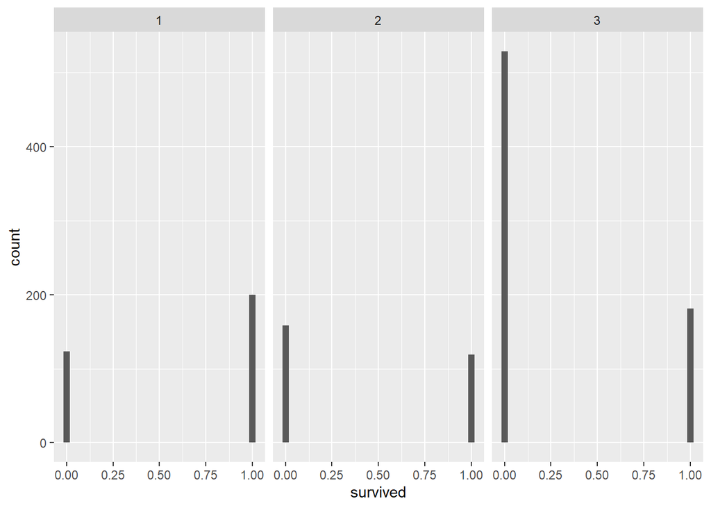

```r
ggplot(titanic, aes(survived)) +
  geom_histogram() +
   facet_wrap(~pclass)
```

0.381971 a teljes tuelesi arany [1] 0.619195 az elso osztaly tuelesi aranya [1] 0.4296029 a 2. osztaly tulelesi aranya [1] 0.2552891 a 3. osztaly tulelelesi aranya

4.b

```r
lpmmodell <-lm(survived~pclass+sex+age, data = titanic)
stargazer(lpmmodell, type="text")
```

```
##
## ===============================================
##                         Dependent variable:
##                     ---------------------------
##                              survived
## -----------------------------------------------
## pclass                       -0.183***
##                               (0.016)
##
## sex                          0.491***
##                               (0.026)
##
## age                          -0.005***
##                               (0.001)
##
## Constant                     0.293***
##                               (0.070)
##
## -----------------------------------------------
## Observations                   1,046
## R2                             0.369
## Adjusted R2                    0.367
## Residual Std. Error      0.391 (df = 1042)
## F Statistic          202.753*** (df = 3; 1042)
## ===============================================
## Note:               *p<0.1; **p<0.05; ***p<0.01
```

```r
logitmodell <- glm(survived~pclass+sex+age, family = binomial(link=logit), data = titanic)
summary(logitmodell)
```

```
##
## Call:
## glm(formula = survived ~ pclass + sex + age, family = binomial(link = logit),
##     data = titanic)
##
## Deviance Residuals:
##     Min       1Q   Median       3Q      Max
## -2.6159  -0.7162  -0.4321   0.6572   2.4041
##
## Coefficients:
##             Estimate Std. Error z value Pr(>|z|)
## (Intercept) -0.40548    0.40795  -0.994     0.32
## pclass      -1.13324    0.11173 -10.143  < 2e-16 ***
## sex          2.49738    0.16612  15.034  < 2e-16 ***
## age         -0.03388    0.00628  -5.395 6.84e-08 ***
## ---
## Signif. codes:  0 '***' 0.001 '**' 0.01 '*' 0.05 '.' 0.1 ' ' 1
##
## (Dispersion parameter for binomial family taken to be 1)
##
##     Null deviance: 1414.62  on 1045  degrees of freedom
## Residual deviance:  983.02  on 1042  degrees of freedom
##   (263 observations deleted due to missingness)
## AIC: 991.02
##
## Number of Fisher Scoring iterations: 4
```

```r
probitmodell <- glm(survived~pclass+sex+age, family = binomial(link=probit), data = titanic)
summary(probitmodell)
```

```
##
## Call:
## glm(formula = survived ~ pclass + sex + age, family = binomial(link = probit),
##     data = titanic)
##
## Deviance Residuals:
##     Min       1Q   Median       3Q      Max
## -2.7201  -0.7362  -0.4370   0.6594   2.4270
##
## Coefficients:
##              Estimate Std. Error z value Pr(>|z|)
## (Intercept) -0.323854   0.244836  -1.323    0.186
## pclass      -0.640537   0.062389 -10.267  < 2e-16 ***
## sex          1.483534   0.093742  15.826  < 2e-16 ***
## age         -0.019074   0.003577  -5.332 9.71e-08 ***
## ---
## Signif. codes:  0 '***' 0.001 '**' 0.01 '*' 0.05 '.' 0.1 ' ' 1
##
## (Dispersion parameter for binomial family taken to be 1)
##
##     Null deviance: 1414.62  on 1045  degrees of freedom
## Residual deviance:  985.59  on 1042  degrees of freedom
##   (263 observations deleted due to missingness)
## AIC: 993.59
##
## Number of Fisher Scoring iterations: 5
```

4.c

```r
library(mfx)
logitmfx(logitmodell, data=titanic, atmean=TRUE)
```

```
## Call:
## logitmfx(formula = logitmodell, data = titanic, atmean = TRUE)
##
## Marginal Effects:
##             dF/dx  Std. Err.        z     P>|z|
## pclass -0.2665864  0.0261318 -10.2016 < 2.2e-16 ***
## sex     0.5512625  0.0293482  18.7835 < 2.2e-16 ***
## age    -0.0079712  0.0014743  -5.4066 6.422e-08 ***
## ---
## Signif. codes:  0 '***' 0.001 '**' 0.01 '*' 0.05 '.' 0.1 ' ' 1
##
## dF/dx is for discrete change for the following variables:
##
## [1] "sex"
```

```r
probitmfx(probitmodell, data=titanic, atmean=TRUE)
```

```
## Call:
## probitmfx(formula = probitmodell, data = titanic, atmean = TRUE)
##
## Marginal Effects:
##             dF/dx  Std. Err.        z     P>|z|
## pclass -0.2461282  0.0239501 -10.2767 < 2.2e-16 ***
## sex     0.5402458  0.0287935  18.7628 < 2.2e-16 ***
## age    -0.0073291  0.0013734  -5.3364 9.482e-08 ***
## ---
## Signif. codes:  0 '***' 0.001 '**' 0.01 '*' 0.05 '.' 0.1 ' ' 1
##
## dF/dx is for discrete change for the following variables:
##
## [1] "sex"
```

```r
exp(coef(logitmodell))
```

```
## (Intercept)      pclass         sex         age
##   0.6666543   0.3219871  12.1505679   0.9666827
```

```r
exp(coef(probitmodell))
```

```
## (Intercept)      pclass         sex         age
##   0.7233557   0.5270093   4.4084986   0.9811072
```

LPM modellnel 18,3%p az atlagos kontrollalt tulelesvaloszinuseg-kulonbseg a 3. es a 2. osztaly kozott

Logitmodellnel 26.65%p az atlagos kontrollalt tulelesvaloszinuseg-kulonbseg 3. es a 2. osztaly kozott

Probitmodell eseten 24,61%p az atlagos kontrollqlt tulelesvaloszinuseg-kulonbseg 3. es a 2. osztaly kozott

4.d

```r
sum(survived==1 & pclass==3)/sum(pclass==3)-sum(survived==1 & pclass==2)/sum(pclass==2)
```

```
## [1] -0.1743137
```

Az a feladatnal a tulelesvaloszinuseg kulonbseg az a 3. es 2. osztaly kozott 17%p volt, a c feladadat mindenhol az a feladatnal nagyobb erteket adott ugyanerre a szamra.